# Mapping parishe emissions: Framlingham as an example

Ben Anderson

Last run at: 2021-09-14 12:13:51

# 1 Intro

Focus on Framlingham (for now, intended to be gneric)

# 2 Mapping parishes

Example: Framlingham

```
## Loading parish boundaries from file
```

```
##  [1] "objectid"   "parncp19cd" "parncp19nm" "parncp19nw" "lad19cd"
##  [6] "lad19nm"    "bng_e"      "bng_n"      "long"       "lat"
## [11] "st_areasha" "st_lengths" "geometry"
```

Build a simple map just to check the size of the parish (Figure 2.1.

[interactive chart not shown]

Figure 2.1: LSOA check map (shows MSOA and ward names when clicked

Now build a simple map from LSOAs based on the Framlingham electoral ward to see how well it matches the parish (Figure 2.2.

```
## Loading LSOA boundaries from file
```

```
##  [1] "OBJECTID"   "LSOA11CD"   "LSOA11NM"   "LSOA11NMW"  "BNG_E"
##  [6] "BNG_N"      "LONG"       "LAT"        "Shape__Are" "Shape__Len"
## [11] "geometry"
```

```
##  [1] "LSOA11CD"        "OBJECTID"        "LSOA11NM.x"      "LSOA11NMW"
##  [5] "BNG_E"           "BNG_N"           "LONG"            "LAT"
##  [9] "Shape__Are"      "Shape__Len"      "LSOA11NM.y"      "MSOA11CD"
## [13] "MSOA11NM"        "LA11CD"          "LA11NM"          "WD20CD"
## [17] "WD20NM"          "LAD20CD"         "LAD20NM"         "i.LSOA11NM"
## [21] "RUC11CD"         "RUC11"           "SOA Code"        "SOA Name"
## [25] "LA Code"         "LA Name"         "Region/Country"  "Supergroup Code"
## [29] "Supergroup Name" "Group Code"      "Group Name"      "geometry"
```

[interactive chart not shown]

Figure 2.2: LSOA check map (shows MSOA and ward names when clicked

```
## Simple feature collection with 5 features and 5 fields
## Geometry type: MULTIPOLYGON
## Dimension:     XY
## Bounding box:  xmin: 621418 ymin: 255244.6 xmax: 636672.1 ymax: 271924.2
## Projected CRS: OSGB 1936 / British National Grid
##    LSOA11CD           LSOA11NM.x  MSOA11CD            MSOA11NM      WD20NM
## 1 E01030154 Suffolk Coastal 002A E02006288 Suffolk Coastal 002 Framlingham
## 2 E01030172 Suffolk Coastal 002B E02006288 Suffolk Coastal 002 Framlingham
## 3 E01030173 Suffolk Coastal 002C E02006288 Suffolk Coastal 002 Framlingham
## 4 E01030174 Suffolk Coastal 002D E02006288 Suffolk Coastal 002 Framlingham
## 5 E01030176 Suffolk Coastal 002E E02006288 Suffolk Coastal 002 Framlingham
##                         geometry
## 1 MULTIPOLYGON (((625178.2 26...
## 2 MULTIPOLYGON (((629668 2660...
## 3 MULTIPOLYGON (((628048.7 26...
## 4 MULTIPOLYGON (((628142.3 27...
## 5 MULTIPOLYGON (((633719.9 26...
```

This map suggests that two LSOAs:

- E01030172 Suffolk Coastal 002B
- E01030173 Suffolk Coastal 002C

Are a close match to the Framlingham civil parish shown in the first map. This will enable us to extract residential gas & electricity use.

Commercial gas & electricity use is at MSOA level. This may exceed the parish boundaries - find E02006288 (see above) and map it - Figure 2.3.

```
## Loading MSOA boundaries from file
```

```
## [1] "objectid"   "msoa11cd"   "msoa11nm"   "msoa11nmw"  "st_areasha"
## [6] "st_lengths" "geometry"
```

```
## [1] "objectid"   "msoa11cd"   "msoa11nm"   "msoa11nmw"  "st_areasha"
## [6] "st_lengths" "geometry"
```

[interactive chart not shown]

Figure 2.3: MSOA check map (shows MSOA and ward names when clicked

Yep, way too big. In fact this looks much like the [Framlingham electoral ward](https://www.suffolk.gov.uk/assets/council-and-democracy/how-the-council-works/SCC-Electoral-Division-Ward-Parish-map.pdf)…

This means we can only get residential electricity & gas at LSOA level and aggregate, all other data is at MSOA or LA level. See CREDS [carbon.place](https://www.carbon.place/) for LSOA emissions estimates or CSE’s impact tool for parish/LA emissions - both of these use the LSOA data for 2018/19 as part of their inputs.

# 3 Energy use

2010 & 2019 residential gas & electricity consumption data from:

- https://www.gov.uk/government/statistics/lower-and-middle-super-output-areas-gas-consumption
- https://www.gov.uk/government/statistics/lower-and-middle-super-output-areas-electricity-consumption

Define Framlingham by selecting the following LSOAs:

- E01030172 Suffolk Coastal 002B
- E01030173 Suffolk Coastal 002C

## 3.1 Gas 2010

Note the ‘old’ local authority label.

```
##               LSOA Name  LSOA11CD      WD20NM Number of meters total_gas_kWh
## 1: Suffolk Coastal 002B E01030172 Framlingham              597       9162457
## 2: Suffolk Coastal 002C E01030173 Framlingham              552       8880551
```

```
## Framlingham: Total number of gas meters = 1149
```

```
## Total residential gas kWh = 18043008
```

Using BEIS gas emissions factors for 2010 (https://www.gov.uk/government/publications/greenhouse-gas-reporting-conversion-factors-2010) doesn’t help - no gas value. Use 2015 - 0.18445 kg CO2e/kWh (it’s roughly constant over time in any case)

```
##               LSOA Name  LSOA11CD      WD20NM Number of meters total_gas_kWh
## 1: Suffolk Coastal 002B E01030172 Framlingham              597       9162457
## 2: Suffolk Coastal 002C E01030173 Framlingham              552       8880551
##    T_co2e_gas
## 1:   1690.015
## 2:   1638.018
```

```
## Total T CO2e from gas  = 3328.0328256
```

## 3.2 Electricity 2010

BEIS CI: 0.48531 kg CO2e/kWh - very high due to use of goal.

```
##                LSOA11NM  LSOA11CD      WD20NM
## 1: Suffolk Coastal 002B E01030172 Framlingham
## 2: Suffolk Coastal 002C E01030173 Framlingham
##    Total number of domestic electricity meters total_elec_kWh
## 1:                                         772        3792823
## 2:                                         726        3256201
```

```
## Total number of elec meters = 1498
```

```
## Total residential elec kWh = 7049024.2
```

The difference between number of gas and electricity meters more or less shows those off-gas - but there could be two electricity meters per house - e.g. anyone using Economy-7.

```
##                LSOA11NM  LSOA11CD      WD20NM
## 1: Suffolk Coastal 002B E01030172 Framlingham
## 2: Suffolk Coastal 002C E01030173 Framlingham
##    Total number of domestic electricity meters total_elec_kWh T_co2e_elec
## 1:                                         772        3792823    1840.695
## 2:                                         726        3256201    1580.267
```

```
## Total T CO2e from electricity  = 3420.961934502
```

```
## Total T CO2e from this much electricity in 2021 using the most recent grid CI factor would be = 1496.719308386
```

[output not shown]

## 3.3 Gas 2019 (latest data, pre-covid)

```
##               LSOA Name  LSOA11CD      WD20NM Number of consuming meters
## 1: Suffolk Coastal 002B E01030172 Framlingham                        805
## 2: Suffolk Coastal 002C E01030173 Framlingham                        821
##    total_gas_kWh
## 1:      10127210
## 2:      10134023
```

```
## Total number of consuming gas meters 2019 = 1626
```

```
## Total residential gas kWh 2019 = 20261232.67
```

Using BEIS gas emissions factors for 2019 (https://www.gov.uk/government/publications/greenhouse-gas-reporting-conversion-factors-2019).

0.18385 kg CO2e/kWh + 0.02391 (WTT)

```
##               LSOA Name  LSOA11CD      WD20NM Number of consuming meters
## 1: Suffolk Coastal 002B E01030172 Framlingham                        805
## 2: Suffolk Coastal 002C E01030173 Framlingham                        821
##    total_gas_kWh T_co2e_gas
## 1:      10127210   2104.029
## 2:      10134023   2105.445
```

```
## Total T CO2e from gas  = 4209.4736995192
```

## 3.4 Electricity 2019 (latest data, pre-covid)

BEIS CI: 0.2556 kg CO2e/kWh + 0.03565 + 0.02170 (WTT + T&D)

```
##                LSOA11NM  LSOA11CD      WD20NM
## 1: Suffolk Coastal 002B E01030172 Framlingham
## 2: Suffolk Coastal 002C E01030173 Framlingham
##    Total number of domestic electricity meters total_elec_kWh
## 1:                                         964        3620935
## 2:                                         981        3264661
```

```
## Total number of elec meters = 1945
```

```
## Total residential elec kWh = 6885595.88
```

The difference between number of gas and electricity meters more or less shows those off-gas - but there could be two electricity meters per house - e.g. anyone using Economy-7.

```
##                LSOA11NM  LSOA11CD      WD20NM
## 1: Suffolk Coastal 002B E01030172 Framlingham
## 2: Suffolk Coastal 002C E01030173 Framlingham
##    Total number of domestic electricity meters total_elec_kWh T_co2e_elec
## 1:                                         964        3620935    1133.172
## 2:                                         981        3264661    1021.676
```

```
## Total T CO2e from electricity  = 2154.847230646
```

## 3.5 2010 - 2019 change

### 3.5.1 Gas 2010-2019

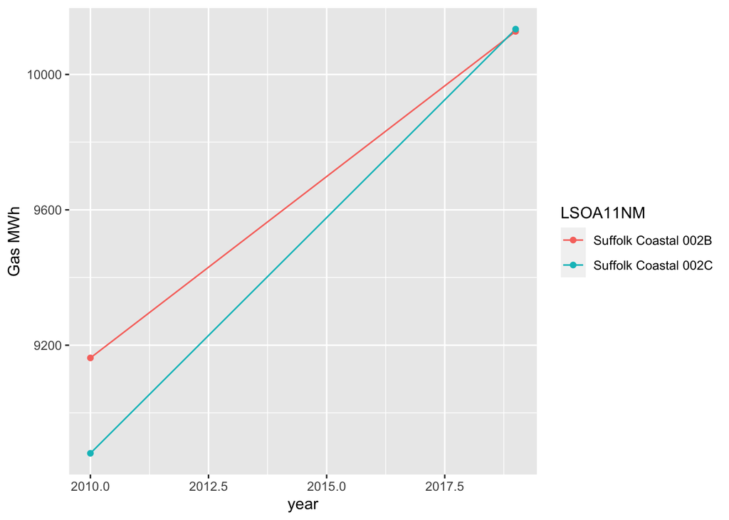

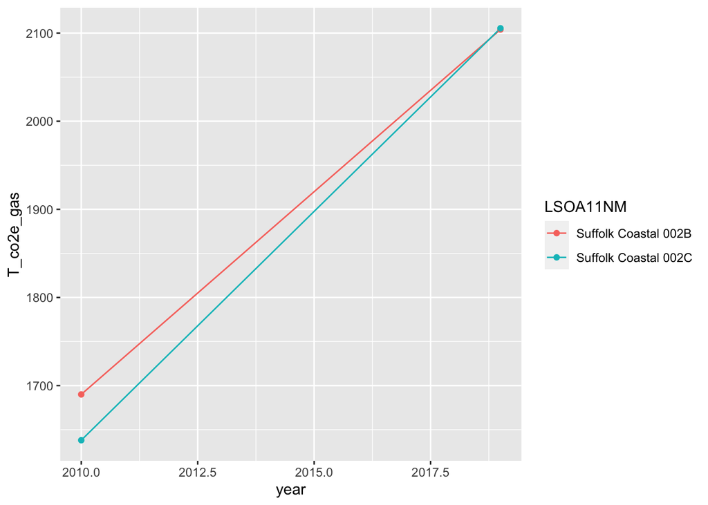

```
##     LSOA11CD             LSOA11NM      WD20NM total_gas_kWh T_co2e_gas nMeters
## 1: E01030172 Suffolk Coastal 002B Framlingham       9162457   1690.015     597
## 2: E01030173 Suffolk Coastal 002C Framlingham       8880551   1638.018     552
## 3: E01030172 Suffolk Coastal 002B Framlingham      10127210   2104.029     805
## 4: E01030173 Suffolk Coastal 002C Framlingham      10134023   2105.445     821
##    year
## 1: 2010
## 2: 2010
## 3: 2019
## 4: 2019
```

```
## Change in number of meters = 477 (42 %)
```

```
## Change in total gas use = 2218.22467 MWh
```

[output not shown]

```
## % change in T CO2e from gas use = 26.49 %
```

```
## Loading /Users/ben/Dropbox/data/beis/subnationalGas/lsoaDom/LSOA_GAS_2010.csv.gz
```

```
## Loading /Users/ben/Dropbox/data/beis/subnationalGas/lsoaDom/LSOA_GAS_2011.csv.gz
```

```
## Loading /Users/ben/Dropbox/data/beis/subnationalGas/lsoaDom/LSOA_GAS_2012.csv.gz
```

```
## Loading /Users/ben/Dropbox/data/beis/subnationalGas/lsoaDom/LSOA_GAS_2013.csv.gz
```

```
## Loading /Users/ben/Dropbox/data/beis/subnationalGas/lsoaDom/LSOA_GAS_2014.csv.gz
```

```
## Loading /Users/ben/Dropbox/data/beis/subnationalGas/lsoaDom/LSOA_GAS_2015.csv.gz
```

```
## Loading /Users/ben/Dropbox/data/beis/subnationalGas/lsoaDom/LSOA_GAS_2016.csv.gz
```

```
## Loading /Users/ben/Dropbox/data/beis/subnationalGas/lsoaDom/LSOA_GAS_2017.csv.gz
```

```
## Loading /Users/ben/Dropbox/data/beis/subnationalGas/lsoaDom/LSOA_GAS_2018.csv.gz
```

```
## Loading /Users/ben/Dropbox/data/beis/subnationalGas/lsoaDom/LSOA_GAS_2019.csv.gz
```

```
##     year  nMeters nConsumingMeters nAllMeters
##  1: 2010 566.2482               NA   566.2482
##  2: 2011 569.1482               NA   569.1482
##  3: 2012 570.9631               NA   570.9631
##  4: 2013 574.9988               NA   574.9988
##  5: 2014 578.9451               NA   578.9451
##  6: 2015       NA         576.1124   576.1124
##  7: 2016       NA         582.9840   582.9840
##  8: 2017       NA         589.0729   589.0729
##  9: 2018       NA         595.1929   595.1929
## 10: 2019       NA         599.2154   599.2154
```

```
##  [1] "Local Authority Name"
##  [2] "Local Authority Code"
##  [3] "MSOA Name"
##  [4] "Middle Layer Super Output Area (MSOA) Code"
##  [5] "LSOA Name"
##  [6] "Lower Layer Super Output Area (LSOA) Code"
##  [7] "Number of meters"
##  [8] "Consumption (kWh)"
##  [9] "Mean consumption (kWh per meter)"
## [10] "Median consumption (kWh per meter)"
## [11] "year"
## [12] "total_gas_kWh"
## [13] "Number of consuming meters"
## [14] "Number of non-consuming meters"
## [15] "total_nMeters"
```

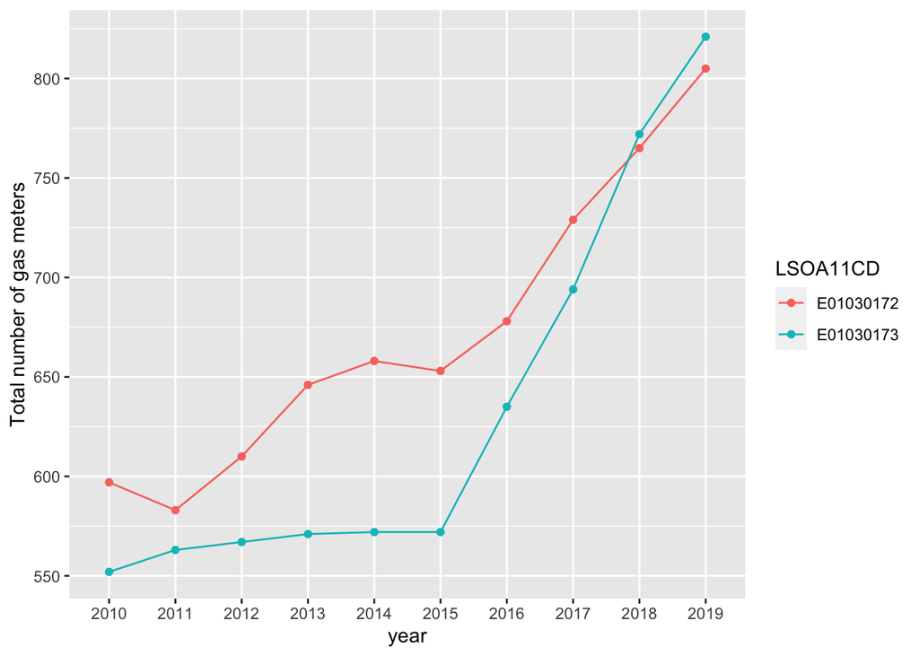

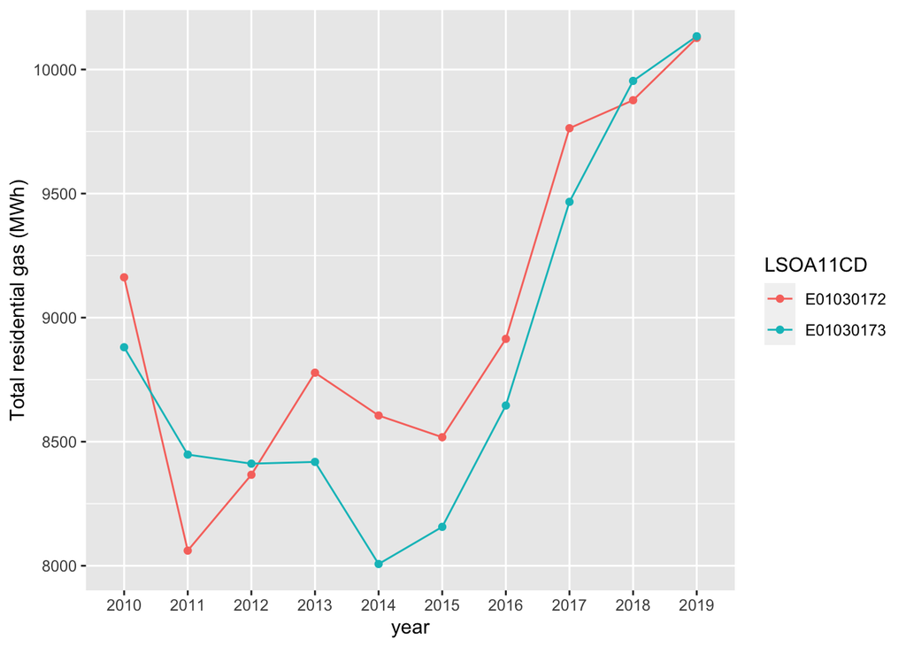

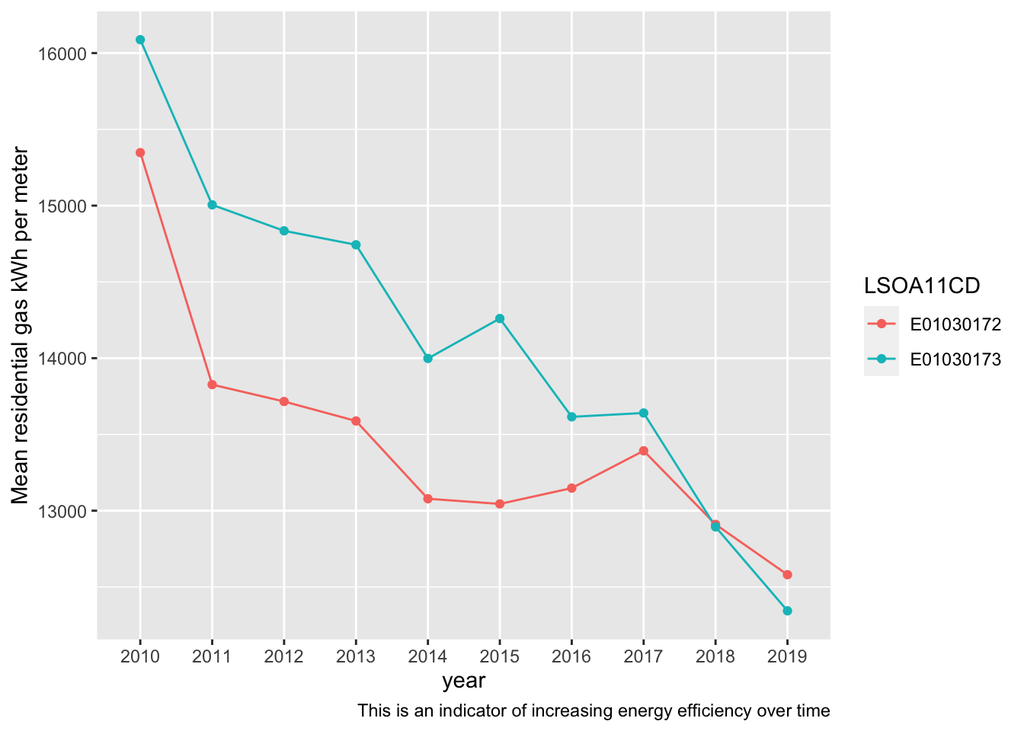

### 3.5.2 Electricity 2010-2019

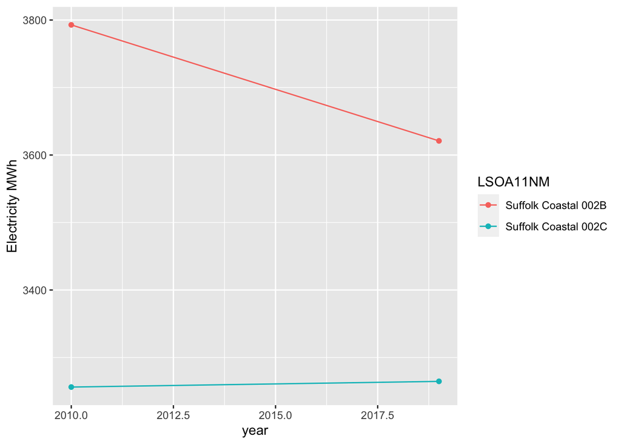

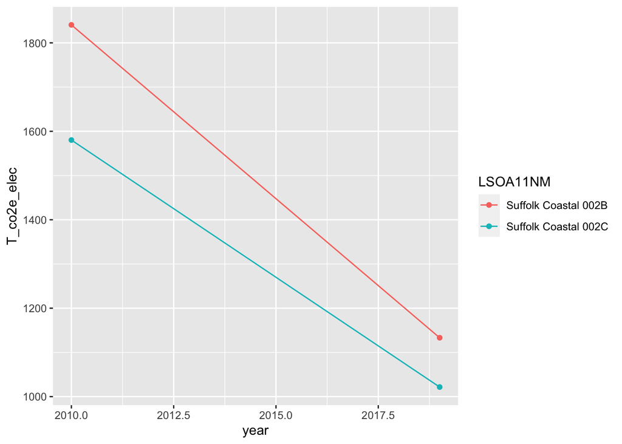

```
##     LSOA11CD             LSOA11NM      WD20NM total_elec_kWh T_co2e_elec
## 1: E01030172 Suffolk Coastal 002B Framlingham        3792823    1840.695
## 2: E01030173 Suffolk Coastal 002C Framlingham        3256201    1580.267
## 3: E01030172 Suffolk Coastal 002B Framlingham        3620935    1133.172
## 4: E01030173 Suffolk Coastal 002C Framlingham        3264661    1021.676
##    nMeters year
## 1:     772 2010
## 2:     726 2010
## 3:     964 2019
## 4:     981 2019
```

```
## Change in number of meters = 447 (30 %) - should probably be about the same as number of gas meters until new builds with electricity only are more common
```

```
## Change in total electricity use = -163.42832 MWh
```

```
## % change in total electricity use = -2.32 %
```

```
## % change in T CO2e from electricity use = -37.01 %
```

```
## Loading /Users/ben/Dropbox/data/beis/subnationalElec/lsoaDom/LSOA_ELEC_2010.csv.gz
```

```
## Loading /Users/ben/Dropbox/data/beis/subnationalElec/lsoaDom/LSOA_ELEC_2011.csv.gz
```

```
## Loading /Users/ben/Dropbox/data/beis/subnationalElec/lsoaDom/LSOA_ELEC_2012.csv.gz
```

```
## Loading /Users/ben/Dropbox/data/beis/subnationalElec/lsoaDom/LSOA_ELEC_2013.csv.gz
```

```
## Loading /Users/ben/Dropbox/data/beis/subnationalElec/lsoaDom/LSOA_ELEC_2014.csv.gz
```

```
## Loading /Users/ben/Dropbox/data/beis/subnationalElec/lsoaDom/LSOA_ELEC_2015.csv.gz
```

```
## Loading /Users/ben/Dropbox/data/beis/subnationalElec/lsoaDom/LSOA_ELEC_2016.csv.gz
```

```
## Loading /Users/ben/Dropbox/data/beis/subnationalElec/lsoaDom/LSOA_ELEC_2017.csv.gz
```

```
## Loading /Users/ben/Dropbox/data/beis/subnationalElec/lsoaDom/LSOA_ELEC_2018.csv.gz
```

```
## Loading /Users/ben/Dropbox/data/beis/subnationalElec/lsoaDom/LSOA_ELEC_2019.csv.gz
```

```
##  [1] "Local Authority Name"
##  [2] "Local Authority Code"
##  [3] "Middle Layer Super Output Area (MSOA) Name"
##  [4] "Middle Layer Super Output Area (MSOA) Code"
##  [5] "Lower Layer Super Output Area (LSOA) Name"
##  [6] "Lower Layer Super Output Area (LSOA) Code"
##  [7] "Total number of domestic electricity meters"
##  [8] "Total domestic electricity consumption (kWh)"
##  [9] "Mean domestic electricity consumption \n(kWh per meter)"
## [10] "Median domestic electricity consumption \n(kWh per meter)"
## [11] "year"
## [12] "total_elec_kWh"
## [13] "total_nMeters"
```

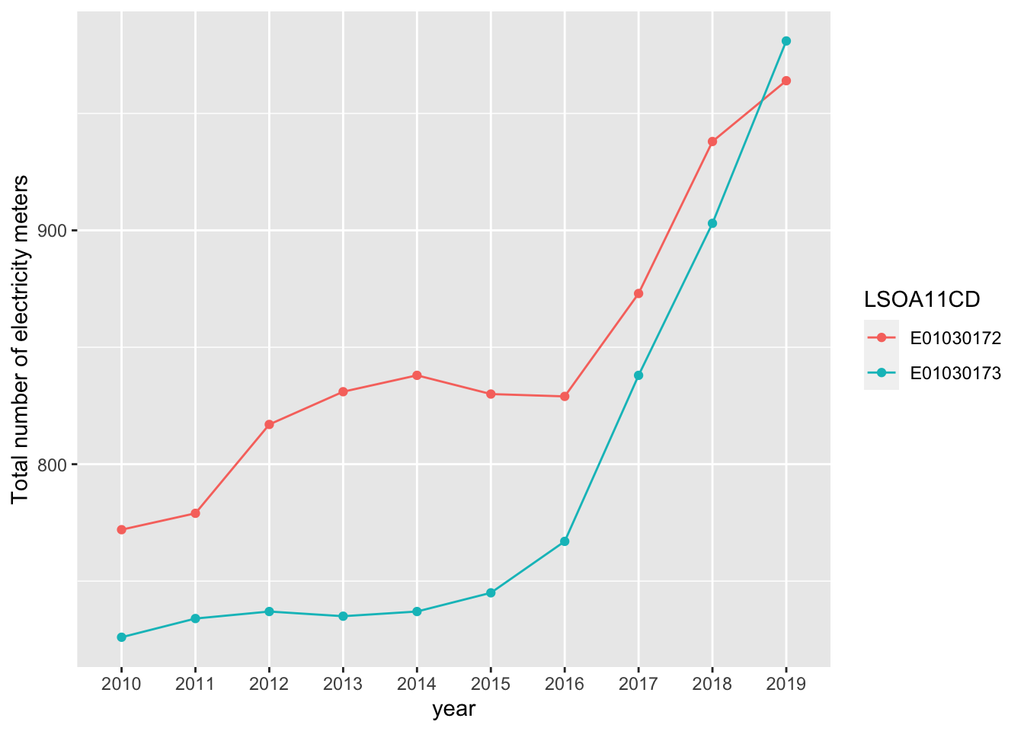

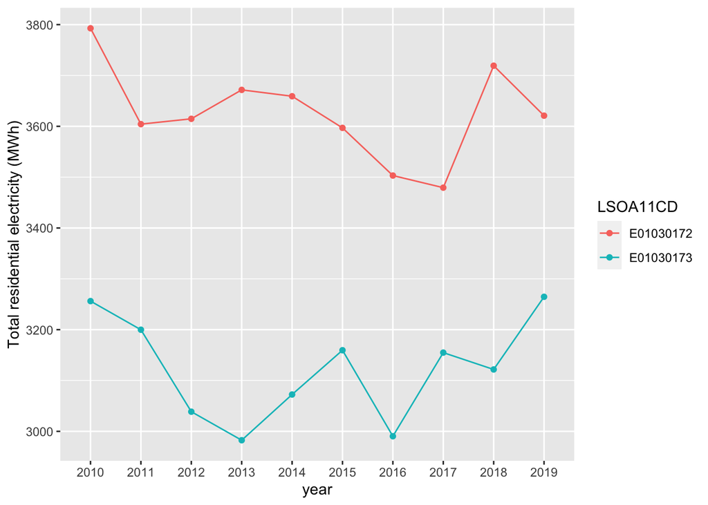

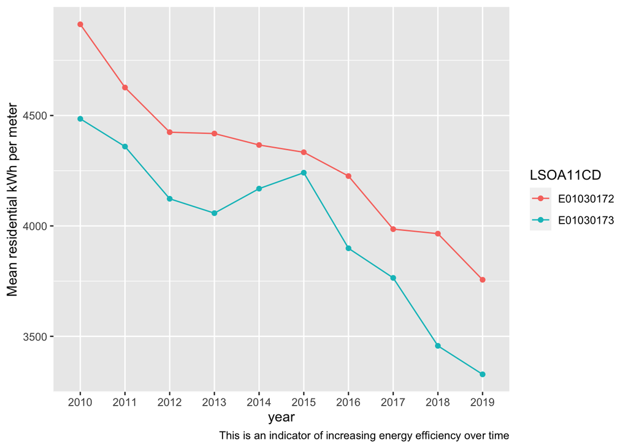

# 4 The end

[output not shown]